# Examining Algorithmic Bias in Criminal Justice Risk Assessments

### Cynthia Hester

##### Final Project - DACSS 604

##### Advanced Data-Driven Storytelling

### Audience

The intended audience for this project consists of educated and inquisitive individuals, most of whom have likely attended college. They understand the implications of artificial intelligence and approach its extensive use in criminal justice and related areas with cautious skepticism. Although this project may appeal to those with diverse interests, the audience does not necessarily possess specific expertise in technology,statistics or criminal justice.

### Introduction

Predictive algorithms and machine learning models, commonly referred to as Risk Assessment Tools (RATs), are increasingly being integrated into the criminal justice system. These tools leverage comprehensive datasets to forecast an individual's likelihood of engaging in future criminal behavior. The deployment of RATs has become widespread, significantly influencing critical legal decisions such as bail settings, sentencing determinations, and parole considerations. The primary motivation behind adopting these predictive models is to enhance the accuracy, fairness, and efficiency of decision-making processes within the judicial system.

However, the implications of inaccuracies in these tools, particularly in terms of false positives (incorrectly predicting future criminal activity) and false negatives (failing to predict actual future criminal activity), are substantial. These errors can have severe consequences, not only for the individuals directly affected but also for broader societal perceptions of justice and fairness.

Disparities in the use of machine learning in criminal justice were notably exposed in ProPublica's "Machine Bias" investigation, which found that the COMPAS (Correctional Offender Management Profiling for Alternative Sanctions) algorithm disproportionately mislabeled black defendants as future criminals compared to white defendants. Furthermore,biases present in the data used to train these algorithms can lead to outcomes that reinforce discriminatory practices. These insights emphasize the critical need to examine the data and methods used in developing risk assessment tools to avoid perpetuating existing societal biases (Yale Law Journal).

The ethical and effective implementation of machine learning in crucial areas such as criminal justice goes beyond academic discussions; it is an urgent societal matter. The lack of transparency in these algorithmic systems often complicates efforts to evaluate their fairness and hold them accountable (MIT Technology Review).

This project seeks to contribute to the ongoing conversation about how machine learning can be responsibly applied in criminal justice, ensuring that technological advances do not come at the expense of equity and justice.

### Data

Data was collected from Broward County Clerk’s Office, Broward County Sherrif's Office, Florida Department of Corrections, via ProPublica Data Store. It represesents years 2013-2014.

https://www.propublica.org/datastore/dataset/compas-recidivism-risk-score-data-and-analysis

### Data Overview

The dataset I'm working with includes two years of data from Broward County, covering the years 2013 to 2014, and focuses on predicting whether individuals are likely to commit a crime again. One key variable, called `two_year_recid`, is central to my analysis. This variable is binary, meaning it can only be a 0 or a 1. A value of 0 means it's unlikely that the individual will reoffend, whereas a 1 indicates a higher likelihood that they will. This binary setup categorizes my analysis as a classification problem, which is different from other types of data analysis that deal with continuous measurements like height or temperature.

I also treat the dataset as independent and uniformly distributed, meaning I consider each data point separate and assume they all come from similar conditions. This assumption is vital for using certain statistical methods and machine learning algorithms effectively, ensuring that the insights I gain from one segment of the data are applicable to the entire set. It also helps prevent issues such as temporal correlations or grouped biases that could compromise the accuracy of my predictions.

Given these parameters—the binary nature of the target variable and the dataset's uniform distribution—I can effectively apply various classification algorithms. This is particularly critical in criminal justice, where precise and unbiased data analysis is essential for making informed decisions.

### Data Visualization

In the analysis of data about individuals who might commit crimes again within two years recidivism, I look into how a person’s age might influence their chances of reoffending. I use a type of chart called a histogram that shows how many people fall into different age categories. This helps highlight any trends, such as whether younger or older individuals are more likely to commit a crime again, making it clearer to see and understand any patterns in the data.

Younger individuals, particularly those from minority racial groups, might be disproportionately predicted to reoffend due to stereotypes or historical data that inaccurately portray their risk. Older adults might be assessed differently, potentially facing less bias due to different societal perceptions of risk associated with age. By analyzing how age intersects with race in predictive models, we can uncover age-specific biases and work towards more accurately tailoring risk assessments. This nuanced understanding is crucial for ensuring that predictive algorithms do not unfairly penalize or favor any group based on age or racial background (Propublica).

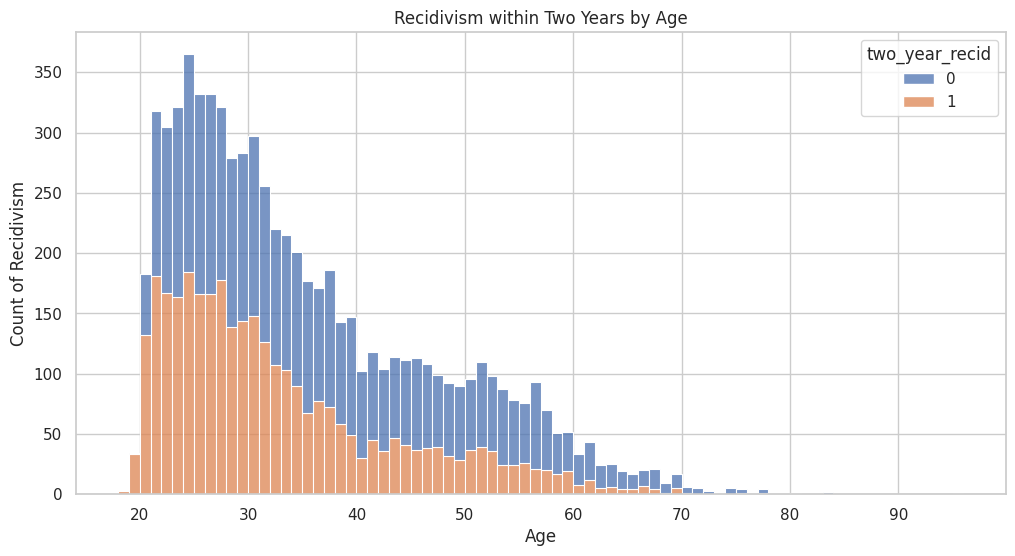

#### Here I use other plots to visualize the data

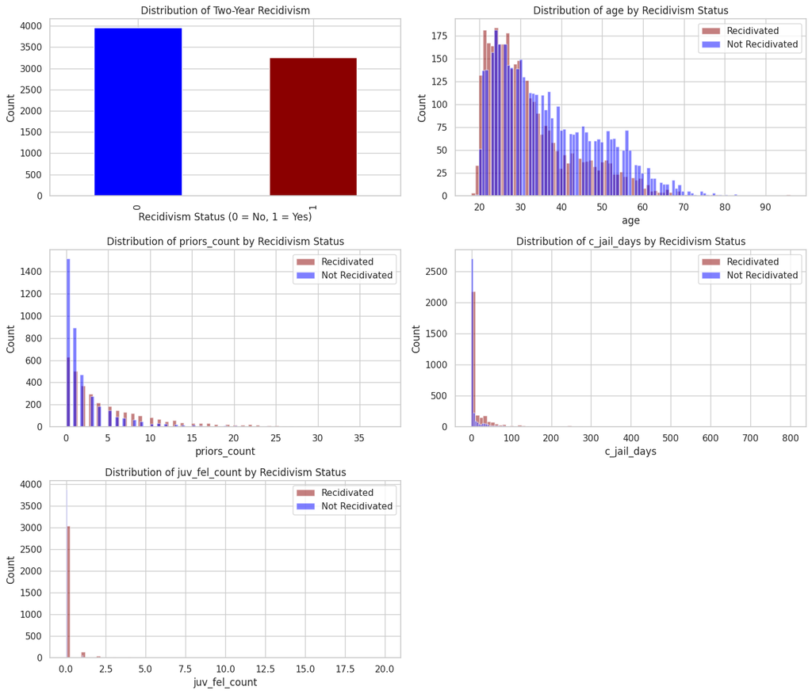

### Data Balance

In this analysis, I focus on understanding how evenly distributed two groups are in our dataset. These groups are labeled 'unlikely to reoffend' (0) and 'likely to reoffend' (1), and the task is to predict which group individuals belong to based on their data.

It's important that these two groups are roughly equal in size because if one group is much larger than the other, it can skew the results. For example, if most people in the dataset are 'unlikely to reoffend,' a model might learn just to predict 'unlikely to reoffend' for everyone. This would make the model appear accurate, but it wouldn’t be very useful since it isn't really assessing each case on its merits.

To check for this, I look at the number of people in each group. If one group is much bigger, I know there might be a bias problem. I also calculate the baseline accuracy, which is how often a very simple model would be right if it always predicted the larger group. This gives me a basic standard to beat, ensuring that any more sophisticated model I develop is actually learning from the data and not just exploiting the imbalance.

The baseline accuracy shows the target variable is slighty imbalanced at 54.93% or 3963 individuals unlikely to commit a crime within 2 years compared to 3251 more likely to commit a crime after being released from prison.

### Observations

Gender can play a significant role in influencing the likelihood of reoffending, and understanding these differences is crucial for developing targeted interventions and policies.

I use a bar chart to simply compare recidivism which is the tendency of a convicted criminal to reoffend between males and females within a two-year period. The data shows a notable difference: although the majority of both males and females did not reoffend, a higher percentage of males did compared to females.

This finding highlights a critical issue with the risk assessment algorithms used in the criminal justice system. These tools need to accurately reflect that women generally have lower recidivism rates. If they don’t, there's a risk that women might be unfairly judged as higher risk than they actually are, potentially leading to unnecessarily harsh consequences like longer prison terms or stricter bail conditions.

Keeping this in mind it's essential that we rigorously evaluate these algorithms to ensure they do not perpetuate gender bias, just as we are cautious about racial bias. This will help make sure that the algorithms aid in achieving fair treatment for everyone, regardless of gender. However, while doing so, we must avoid overly simple conclusions that may overlook other influencing factors such as employment status, housing stability, and educational attainment.

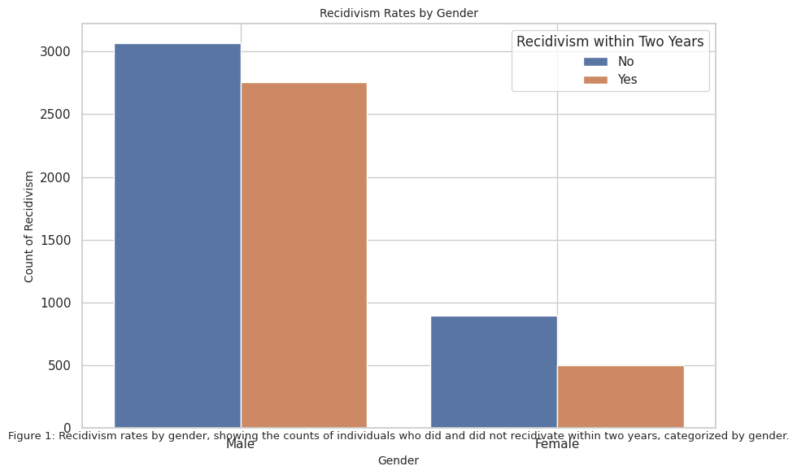

Comparing recidivism rates across different racial groups, the visualization can reveal disparities that may exist in the patterns of reoffending, which is crucial for understanding and addressing systemic biases within the criminal justice system.

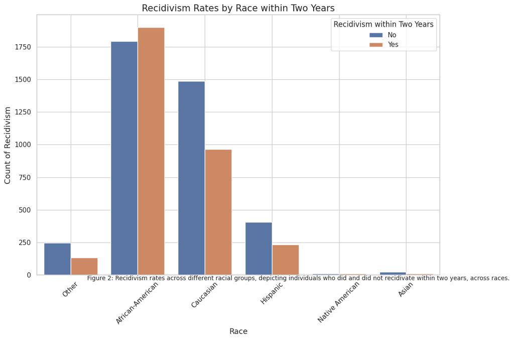

#### Frequency/count of recidivism vs Gender and Race

[figure not shown]

#### Logistic Regression

I chose logistic regression for this analysis because it's simple and particularly good at solving problems where there are only two possible outcomes, such as predicting whether someone will reoffend within two years. The method uses the Broward County data we have to estimate the likelihood of each outcome. For our study, the accuracy of the predictions was about 71%, meaning the model correctly predicted whether individuals would reoffend in approximately 71 out of 100 cases.

```
0.7075537075537075
```

#### Test of model using mean/average and standard deviation

In the recidivism project, I used the mean (average) and standard deviation to evaluate how well the model predicts whether someone will reoffend. Here’s why I used these statistical measures:

1. **Mean (Average):** The mean of the test accuracy scores gives a straightforward way to understand, on average, how accurate the model's predictions are. By calculating the mean score from all test results, we can see the overall effectiveness of the model. For instance, a mean test score tells us the average percentage of times the model correctly predicted whether individuals would reoffend.
2. **Standard Deviation:** This measure tells shows how much the accuracy scores vary from the mean. A lower standard deviation means that the scores are more consistent and closer to the mean score, indicating that the model performs reliably across different sets of data. A higher standard deviation would suggest that the model’s performance varies significantly, which might indicate that it doesn’t perform equally well in all scenarios.

By looking at both the mean and the standard deviation, we can get a full picture of the model's performance — not just how well it does on average, but also how dependable its predictions are across different situations. This is crucial for ensuring that the model is both accurate and reliable in its predictions about recidivism.

```
Mean Test Score: 0.8518
Standard Deviation of Test Scores: 0.0109
```

### Results and Analysis

In my analysis of the recidivism dataset, I've decided to look at how well the model predicts outcomes for different racial groups, particularly Caucasian and African American individuals, since they appear more frequently in the data. I use tools called confusion matrices to see how accurate the model is for each group. These matrices show not only how often the model is right overall, but also how well it identifies correct cases of recidivism (true positives) and correct cases where recidivism does not occur (true negatives). They also show where the model makes mistakes, either by wrongly predicting recidivism (false positives) or missing it when it does happen (false negatives).

This detailed approach helps check if the model is fair and does not favor one group over another. It’s important because sometimes, using only overall accuracy to evaluate a model can be misleading. This is especially true in datasets where the numbers of one outcome are much higher than the other. For instance, if there are many more cases of non-recidivism than recidivism, a model might seem accurate simply because it frequently predicts non-recidivism, without truly capturing the less common cases of recidivism. Moreover, accuracy alone doesn't tell us about the different types of mistakes the model makes, which can have varying impacts. For example, wrongly predicting that someone will reoffend might have different consequences than missing a prediction for someone who does reoffend. This consideration is crucial for ensuring the analysis is both effective and fair.

```
Accuracy for Male: 0.84
Accuracy for Female: 0.88
Accuracy for Caucasian: 0.88
Accuracy for African-American: 0.83
```

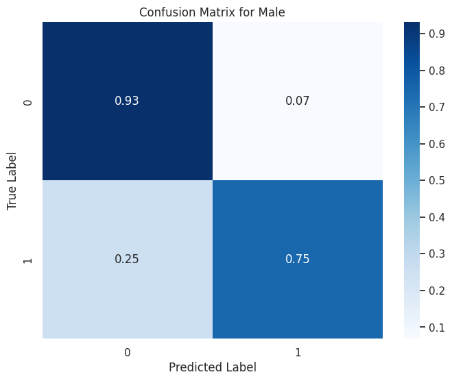

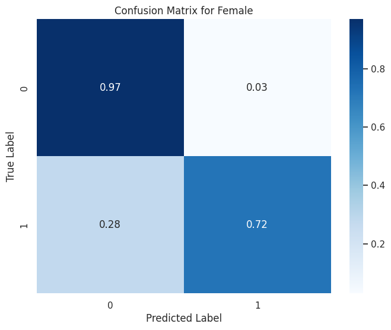

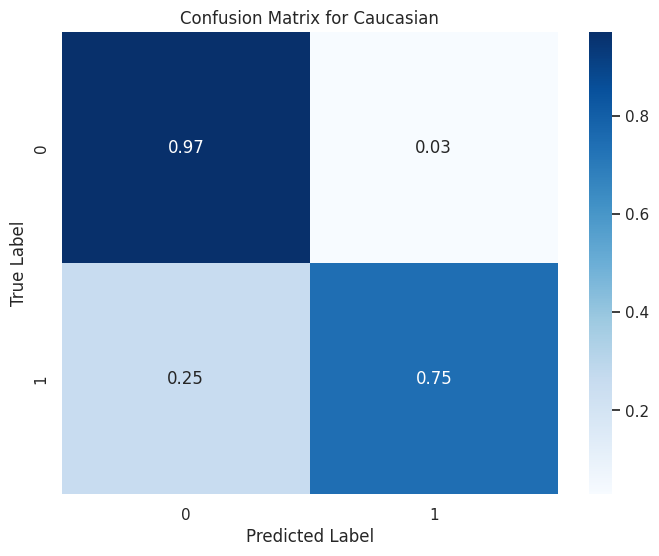

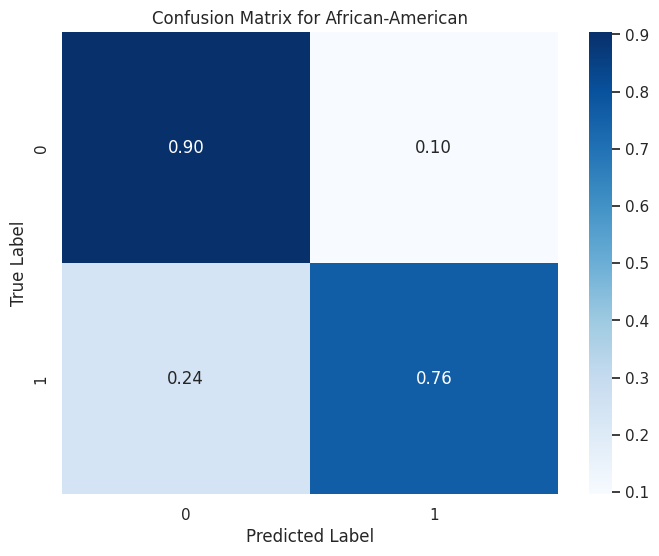

#### Key Takeaways

A false positive in this context means the model incorrectly predicts that someone will reoffend when they won't. This can lead to unfairly severe consequences, like harsher sentences, particularly affecting African American men. The investigative report by ProPublica on machine bias highlighted similar concerns, showing that such predictive models could perpetuate existing biases in the criminal justice system. The report argued that relying solely on these models for sentencing could lead to unjust decisions.

Given the potential consequences of these errors, it's crucial that such predictive models are used with great caution. They should not be the only factor in making judicial decisions. Instead, a more comprehensive approach that considers multiple aspects and checks for bias should be used to ensure fair treatment in the justice system.

### Conclusion

Moving forward, addressing AI bias in criminal justice demands robust, continuous oversight to monitor the performance and impact of these risk assessment tools. This involves not only regular audits by independent experts but also implementing mechanisms for feedback and adaptation based on those findings. Maintaining high levels of transparency is equally crucial; this means making the methodologies, data sources, and decision-making processes of AI tools accessible and understandable to all stakeholders, including the public(MIT Technology Review). This transparency helps build trust and facilitates informed critique and suggestions for improvement.

Moreover, fostering interdisciplinary collaboration is essential in the design and application of these technologies. By bringing together experts from fields such as computer science, law, ethics, sociology, and psychology, we can ensure that diverse perspectives inform the development of AI tools. This collaboration can help identify potential biases and devise strategies to mitigate them before they affect decision-making processes. Such thorough and collaborative efforts are key to harnessing the benefits of AI in criminal justice while safeguarding against its potential to perpetuate or exacerbate injustice.

### References

Angwin, J., Larson, J., Mattu, S., & Kirchner, L. (2016, May 23). Machine bias. ProPublica. https://www.propublica.org/article/machine-bias-risk-assessments-in-criminal-sentencing

Hao, K. (2019, January 21). AI is sending people to jail—and getting it wrong. MIT Technology Review. https://www.technologyreview.com/2019/01/21/137783/algorithms-criminal-justice-ai/

Lowenkamp, C. T., Johnson, J. L., Holsinger, A. M., VanBenschoten, S. W., & Robinson, C. R. (2012). The Federal Post Conviction Risk Assessment (PCRA): A construction and validation study. Psychological Services. Advance online publication. https://doi.org/10.1037/a0030343

Mayson, S. G. (2019). Bias in, bias out. Yale Law Journal, 128(8), 2218-2300. https://www.yalelawjournal.org/article/bias-in-bias-out

Selbst, A. D. (2017). Disparate impact in big data policing. Georgia Law Review, 52(1), 109-195. Retrieved from https://digitalcommons.law.uga.edu/cgi/viewcontent.cgi?article=2165&context=fac_artchop

Skeem, J. L., & Lowenkamp, C. T. (2016). Risk, race, and recidivism: Predictive bias and disparate impact. SSRN Electronic Journal. https://doi.org/10.2139/ssrn.